# p8105_hw7_cgd2137

Carolina Downie

11/18/2017

## Problem 1

```r
library(ggplot2)
library(tidyverse)
set.seed(10)

iris_with_missing = iris %>%
  map_df(~replace(.x, sample(1:150, 20), NA)) %>%
  mutate(Species = as.character(Species))
```

```r
replace_missing<- function(df) {
  mean_value <- df %>% mean(na.rm = TRUE) %>% round(., 1)
  virginica<-c("virginica")

  if (is.character(df)) {
    df %>% replace(., is.na(df), virginica)
  } else if (is.numeric(df)) {
    df %>% replace(., is.na(df), mean_value)
  }
}
```

If I wanted to apply this function to one particular column in the dataset, I would specify column in the function input, e.g.:

```r
replace_missing(iris_with_missing$Sepal.Length)
```

```
##   [1] 5.1 4.9 4.7 4.6 5.0 5.4 5.9 5.0 4.4 4.9 5.4 4.8 5.9 4.3 5.8 5.9 5.4
##  [18] 5.1 5.7 5.1 5.4 5.1 4.6 5.1 4.8 5.0 5.0 5.2 5.2 4.7 4.8 5.4 5.9 5.5
##  [35] 4.9 5.9 5.5 4.9 5.9 5.9 5.0 4.5 4.4 5.0 5.1 5.9 5.1 4.6 5.9 5.0 7.0
##  [52] 6.4 5.9 5.5 6.5 5.7 6.3 5.9 6.6 5.2 5.9 5.9 6.0 5.9 5.6 6.7 5.6 5.8
##  [69] 6.2 5.6 5.9 6.1 6.3 6.1 6.4 6.6 5.9 6.7 5.9 5.7 5.5 5.9 5.8 6.0 5.4
##  [86] 6.0 6.7 5.9 5.6 5.5 5.5 5.9 5.8 5.0 5.6 5.7 5.7 6.2 5.1 5.7 6.3 5.9
## [103] 7.1 6.3 6.5 7.6 4.9 7.3 6.7 5.9 6.5 6.4 6.8 5.7 5.8 6.4 6.5 7.7 7.7
## [120] 6.0 6.9 5.6 7.7 6.3 6.7 7.2 6.2 6.1 6.4 7.2 7.4 7.9 6.4 6.3 6.1 7.7
## [137] 6.3 6.4 6.0 6.9 6.7 6.9 5.8 6.8 6.7 6.7 6.3 6.5 6.2 5.9
```

Since I want to apply this function to each column in the dataset, I will apply it across the dataset using the map function:

```r
iris_replace_missing <- map(iris_with_missing, replace_missing) %>% data.frame()
```

If I want to change the summary measure that is used to fill in the numeric NA cells, I need to add that as an additional argument in the function:

```r
replace_missing_update <- function(df, summary_stat) {

  summary_value <- df %>% summary_stat(., na.rm = TRUE) %>% round(., 1)
  virginica<-c("virginica")

  if (is.character(df)) {
    df %>% replace(., is.na(df), virginica)
  } else if (is.numeric(df)) {
    df %>% replace(., is.na(df), summary_value)
  }
}
```

```r
iris_replace_missing_mean <- map(iris_with_missing, replace_missing_update, mean) %>% data.frame()
iris_replace_missing_median <- map(iris_with_missing, replace_missing_update, median) %>% data.frame()
```

## Problem 2

Loading and tidying data:

```r
library(janitor)
airbnb_data <- read_csv("../data/nyc_airbnb.csv") %>%
  clean_names() %>%
  mutate(rating = review_scores_location / 2) %>%
  select(boro = neighbourhood_group, neighbourhood, rating, price, room_type,
         latitude, longitude)
```

Nesting data frame within boro:

```r
airbnb_data_nest<-nest(airbnb_data, neighbourhood:longitude)
```

Nesting the airbnb_data dataset within boro results in a new dataset with 5 observations and 2 variables: borough name (boro), and the corresponding list columns (data) that contain all the information about neighborhoods, rating, price, room_type, latitude, and longitude for each borough.

*Rental Price by Rating*

This is a continuous predictor variable

```r
#Rating

   airbnb_data_nest %>%
  mutate(model = map(data, ~lm(price ~ rating, data = .x)),
         results = map(model, broom::tidy)) %>%
  select(-data, -model) %>%
  unnest() %>% knitr::kable()
```

| boro | term | estimate | std.error | statistic | p.value |
| --- | --- | --- | --- | --- | --- |
| Bronx | (Intercept) | 49.925497 | 18.333805 | 2.7231389 | 0.0067092 |
| Bronx | rating | 4.913398 | 4.100987 | 1.1981011 | 0.2314866 |
| Queens | (Intercept) | 18.096791 | 26.305894 | 0.6879368 | 0.4915484 |
| Queens | rating | 15.799563 | 5.631629 | 2.8055048 | 0.0050577 |
| Brooklyn | (Intercept) | -11.348785 | 14.481690 | -0.7836644 | 0.4332517 |
| Brooklyn | rating | 27.993043 | 3.103038 | 9.0211719 | 0.0000000 |
| Staten Island | (Intercept) | 99.242209 | 59.671890 | 1.6631316 | 0.0979885 |
| Staten Island | rating | -1.788185 | 12.869975 | -0.1389424 | 0.8896476 |
| Manhattan | (Intercept) | -34.304391 | 22.925709 | -1.4963284 | 0.1345898 |
| Manhattan | rating | 43.303460 | 4.776577 | 9.0657931 | 0.0000000 |

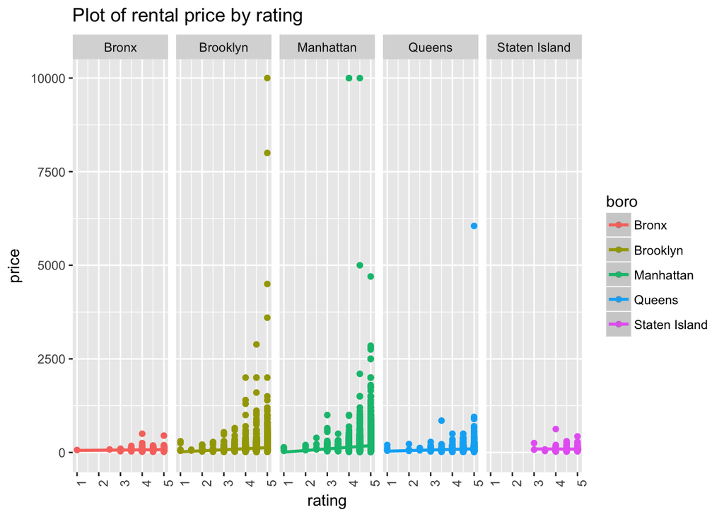

```r
airbnb_data %>%
  ggplot(aes(x = rating, y = price, group = boro, color = boro)) +
    geom_point() +
    geom_smooth(method = "lm", formula = y ~ x) +
  facet_grid(. ~ boro) +
  labs(
    title = "Plot of rental price by rating") +
   theme(axis.text.x = element_text(angle = 90, hjust = 1))
```

The table of slope and intercept values suggest that for all boroughs except Staten Island, there is a positive relationship between rating and price. However, looking at the plots, it appears that the relationship between rating and rental price is not linear and therefore a linear model is not a great model for this data.

*Rental Price by Room Type*

This is a categorical variable with three possible options: entire home/apt, private room, or shared room, therefore we need 2 dummy variables (k-1). When we run the linear model, “Entire home/apt” is set as the reference variable.

```r
#Room Type
  airbnb_data_nest %>%
  mutate(model = map(data, ~lm(price ~ room_type, data = .x)),
         results = map(model, broom::tidy)) %>%
  select(-data, -model) %>%
  unnest() %>% knitr::kable()
```

| boro | term | estimate | std.error | statistic | p.value |
| --- | --- | --- | --- | --- | --- |
| Bronx | (Intercept) | 125.14062 | 5.224513 | 23.9525891 | 0.0000000 |
| Bronx | room_typePrivate room | -59.59517 | 6.285836 | -9.4808671 | 0.0000000 |
| Bronx | room_typeShared room | -67.64062 | 14.644622 | -4.6188029 | 0.0000047 |
| Queens | (Intercept) | 139.94308 | 3.160442 | 44.2795930 | 0.0000000 |
| Queens | room_typePrivate room | -69.30453 | 4.021799 | -17.2322205 | 0.0000000 |
| Queens | room_typeShared room | -90.88579 | 9.066209 | -10.0246737 | 0.0000000 |
| Brooklyn | (Intercept) | 174.91302 | 2.058526 | 84.9700170 | 0.0000000 |
| Brooklyn | room_typePrivate room | -98.26135 | 2.781085 | -35.3320173 | 0.0000000 |
| Brooklyn | room_typeShared room | -115.31250 | 9.295710 | -12.4049157 | 0.0000000 |
| Staten Island | (Intercept) | 206.65517 | 30.301660 | 6.8199291 | 0.0000000 |
| Staten Island | room_typePrivate room | -141.26628 | 40.716632 | -3.4694982 | 0.0006109 |
| Staten Island | room_typeShared room | -181.65517 | 327.762568 | -0.5542279 | 0.5799029 |
| Manhattan | (Intercept) | 238.42334 | 2.199974 | 108.3755490 | 0.0000000 |
| Manhattan | room_typePrivate room | -131.92232 | 3.397005 | -38.8348943 | 0.0000000 |
| Manhattan | room_typeShared room | -153.68273 | 9.703336 | -15.8381328 | 0.0000000 |

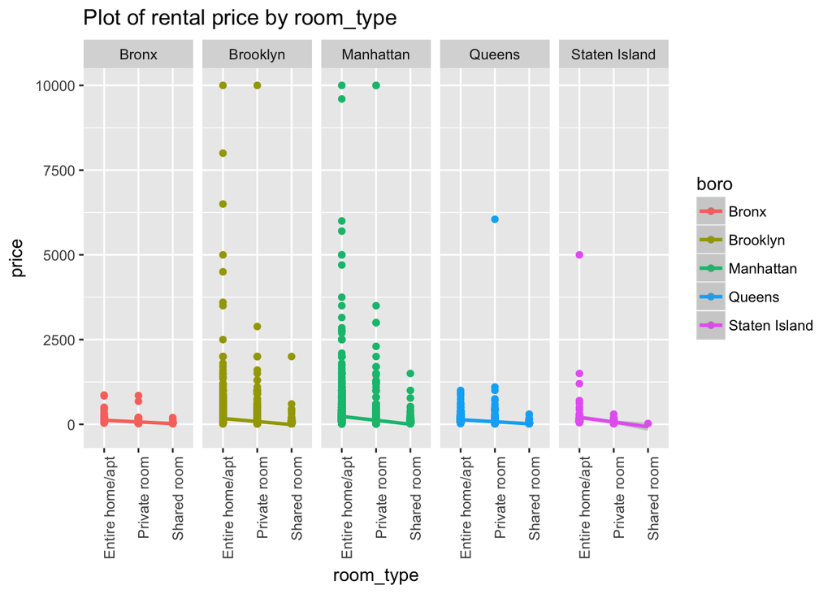

```r
airbnb_data %>%
  ggplot(aes(x = room_type, y = price, group = boro, color = boro)) +
    geom_point() +
    geom_smooth(method = "lm", formula = y ~ x) +
  facet_grid(. ~ boro) + labs(
    title = "Plot of rental price by room_type") +
   theme(axis.text.x = element_text(angle = 90, hjust = 1))
```

The table of slope and intercept values show that for all 5 boroughs, there is a negative relationship between price and room type when room_type “Entire house/apartment” is the reference value. However, again when lookingt at the plots, it appears that the relationship between room type and rental price is not linear and therefore a linear model is not a great model for this data.

## Problem 3

```r
sim_regression <- function(n = 30, beta0 = 1, beta1 =1, beta2, var) {
  sim_data <- tibble(
    xi1 = rnorm(n, 0, 1),
    xi2 = rnorm(n, 0,1),
    y= beta0 +beta1*xi1 + beta2*xi2 + rnorm(n, 0, var)
  )
  ls_fit = lm(y ~ xi1 + xi2, data = sim_data)

  tibble(
  beta2_real = beta2,
  beta2_hat = summary(ls_fit)$coefficients[3,1],
  pvalue = summary(ls_fit)$coefficients[3,4]

  )
}

beta2_0 <- rerun(5,sim_regression(n=30, beta0=1, beta1=1, beta2 = 0, var = 50)) %>% bind_rows()
```

Repeat the above for β2={1,2,3,4,5,6}–since we’re going to be repeating this multiple times, we should make a new function and use a map function to apply it across multiple options for beta2

```r
simulate_beta2<- function(n_rep, beta2) {
  rerun(n_rep, sim_regression(n=30, beta0=1, beta1=1, beta2, var = 50)) %>% bind_rows()
}

beta2_options<-c(0:6)

beta2_estimates <- map_df(beta2_options, simulate_beta2, n_rep = 10000)
```

Making a plot showing the proportion of times the null was rejected (the power of the test) on the y axis and the true value of β2 on the x axis:

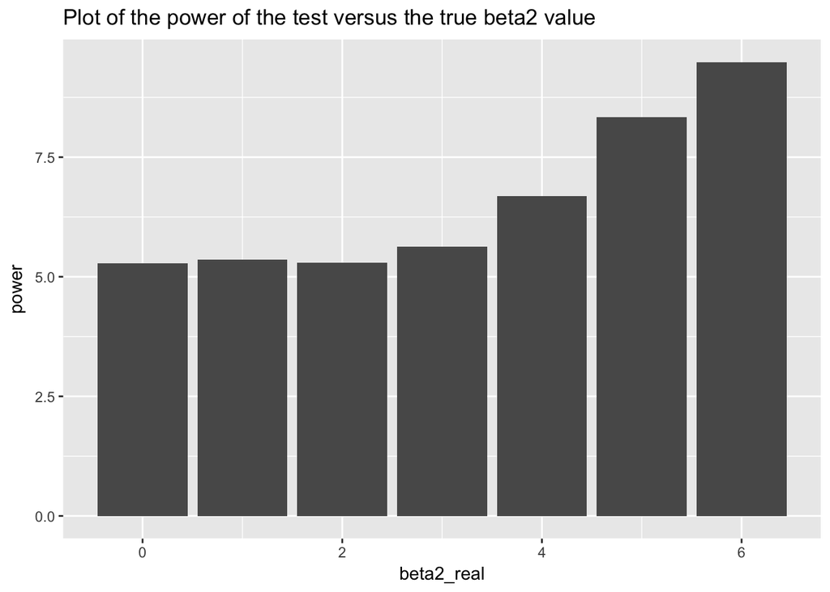

```r
beta2_estimates %>% group_by(beta2_real) %>%
  mutate(n_tests = n()) %>%
 filter(pvalue < 0.05) %>%
  group_by(beta2_real) %>%
  mutate(reject = n(), power = reject/n_tests*100) %>%
  select(beta2_real, power) %>%
  unique() %>%
  ggplot(aes(x = beta2_real, y = power)) +
  geom_bar(stat = "identity") + labs(
    title = "Plot of the power of the test versus the true beta2 value"
  )
```

This plot shows that as effect size increases, the power increases.

Making a plot showing the average estimate of β̂2 on the y axis and the true value of β2 on the x axis:

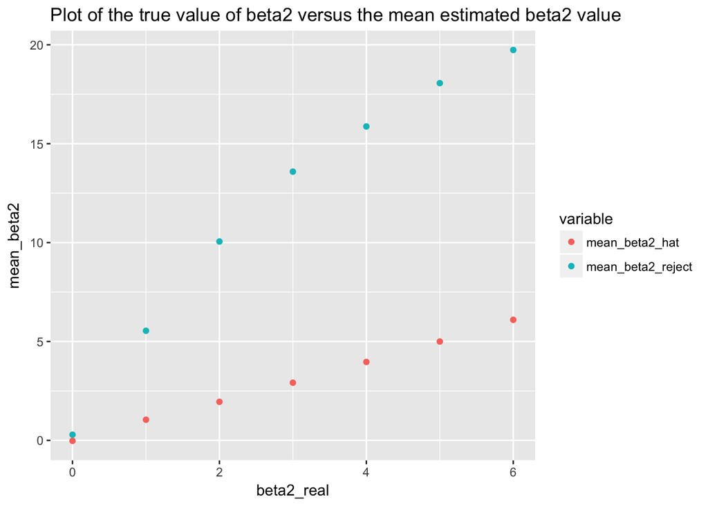

```r
beta2_hat <- beta2_estimates %>% group_by(beta2_real) %>%
  mutate(mean_beta2 = mean(beta2_hat), variable = "mean_beta2_hat") %>%
  select(beta2_real, mean_beta2, variable) %>%
  unique()

beta2_reject <- beta2_estimates %>% filter(pvalue < 0.05) %>%
  group_by(beta2_real) %>%
  mutate(mean_beta2 = mean(beta2_hat), variable = "mean_beta2_reject") %>%
  select(beta2_real, mean_beta2, variable) %>%
  unique()

beta2_summary <- rbind(beta2_hat, beta2_reject)

beta2_summary %>%
  ggplot(aes(x = beta2_real, y = mean_beta2, col = variable)) +
  geom_point() + labs(
    title = "Plot of the true value of beta2 versus the mean estimated beta2 value"
  )
```

As this plot shows, the sample averages of beta2_hat across tests for which the null is rejected are not approximately equal to the true value of β2. This makes sense–in order for the null hypothesis that β2= beta2_real to be rejected, we would expect that the estimated β2 is far from the true β2 value.

## Problem 4

What I want to do is apply the bootstrap to the simulated dataset `sim_df_const` to obtain theta_hat–to do this, I need to create a function to generate `sim_df_const` with different sample sizes, then apply the bootstrap to the results of this simulation, and then calculate a linear model and extract the parameter estimates:

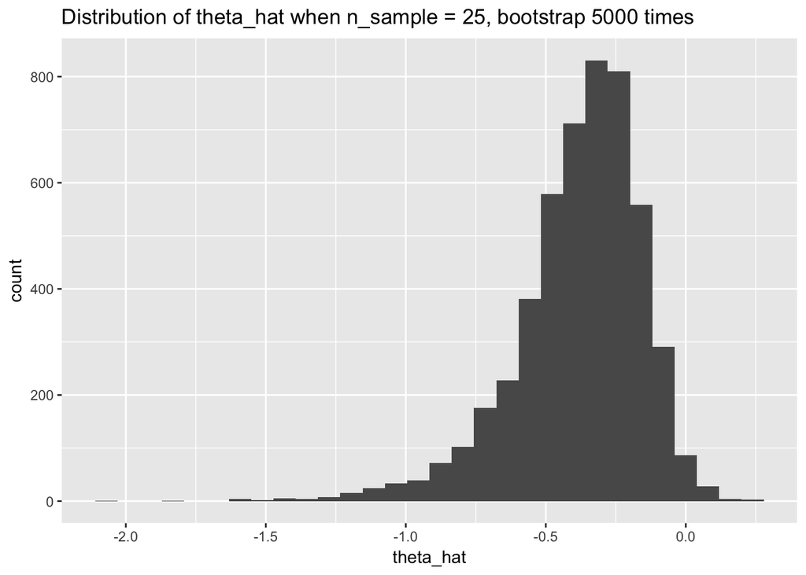

```r
library(modelr)

sim_df_const_function <- function(n_samp){
  set.seed(1)
  tibble(
  x = rnorm(n_samp, 1, 1),
  error = rnorm(n_samp, 0, 1),
  y = 2 + 3 * x + error
)
}

sim_df_const_function(25) %>%
  bootstrap(n = 5000) %>%
  mutate(models = map(strap, ~lm(y ~ x, data = .x)),
         results = map(models, broom::tidy)) %>%
  select(results) %>%
  unnest() %>%
  select(term, estimate) %>%
  group_by(term) %>%
  mutate(test_id = c(1:n())) %>%
  spread(term, estimate) %>%
  rename(beta0_hat = '(Intercept)', beta1_hat = 'x') %>%
  mutate(theta_hat = log(beta0_hat/beta1_hat)) %>%
  ggplot(aes(x = theta_hat)) +
  geom_histogram() + labs(
    title = "Distribution of theta_hat when n_sample = 25, bootstrap 5000 times"
  )
```

Since I want to repeat this procedure more than 2 times, changing n_samp each time, I need to put this process into another function:

```r
sim_df <- function(n_samp, n) {
  sim_df_const_function(n_samp) %>%
  bootstrap(n) %>%
  mutate(models = map(strap, ~lm(y ~ x, data = .x)),
         results = map(models, broom::tidy)) %>%
  select(results) %>%
  unnest() %>%
  select(term, estimate) %>%
  group_by(term) %>%
  mutate(test_id = c(1:n())) %>%
  spread(term, estimate) %>%
  rename(beta0_hat = '(Intercept)', beta1_hat = 'x') %>%
  mutate(theta_hat = log(beta0_hat/beta1_hat)) %>%
  ggplot(aes(x = theta_hat)) +
  geom_histogram()
}
```

Sample size of the simulated dataset is 50:

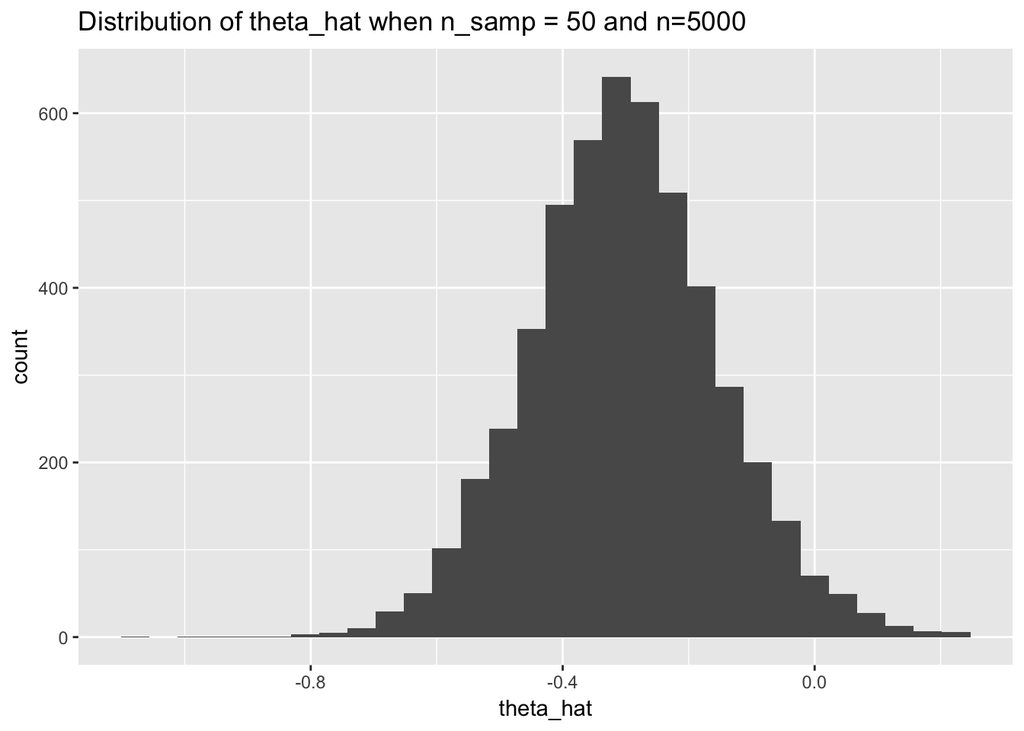

```r
sim_df(n_samp=50, n=5000) + labs(title = "Distribution of theta_hat when n_samp = 50 and n=5000")
```

Sample size of the simulated dataset is 250:

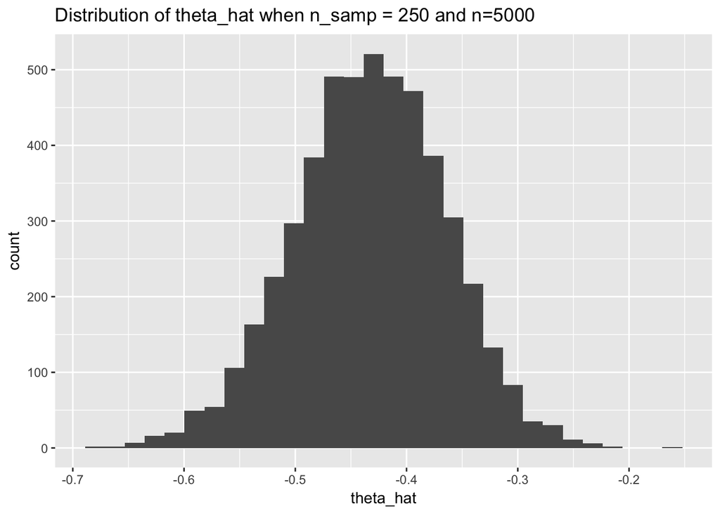

```r
sim_df(n_samp=250, n=5000) + labs(title = "Distribution of theta_hat when n_samp = 250 and n=5000")
```

As we can see from these plots, as n_sample, sample size of the simulated dataset increases, the distributions of theta_hat become less skewed (the tails on both sides are more even), and the distributions shift to the left (more negative), which means that beta0_hats are smaller than beta1_hats, since it is on the log scale.